# Spatial Data in R

## the `sf` package

- The `sf` (simple features) package is a new(ish) way to interact with spatial data that simplifies dealing with spatial data in R.
- It simplifies the storage of spatial data into a dataframe with a special column called `geometry`.
- This `geometry` column allows R to plot real maps (to scale), and allows you to do lots of geospatial analyses.

## actual spatial data versus coordinates

We often just have coordinate data, but this works differently in R from fully spatial data

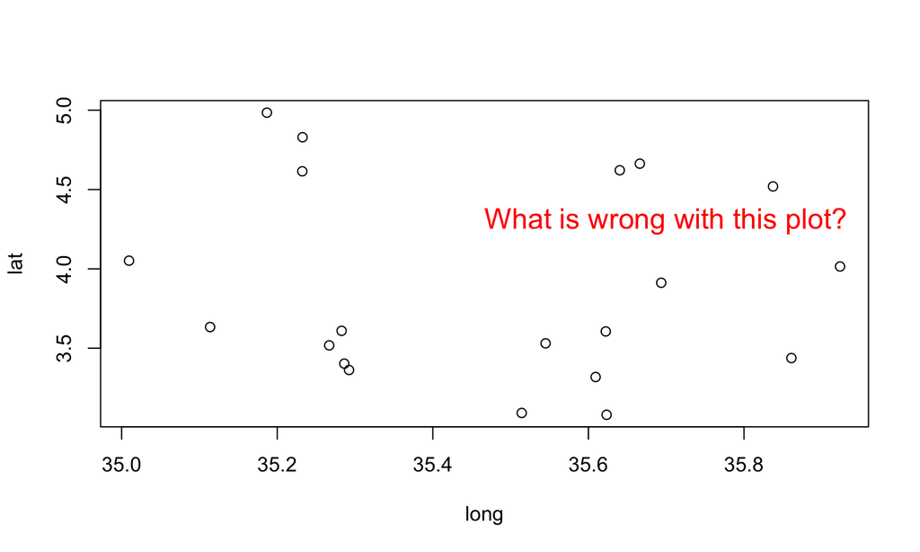

```r
myCoords <- data.frame(long = runif(20, min=35, max=36), lat = runif(20, min = 3, max=5))
plot(myCoords)
```

## making spatial objects

For a gold star: Which is the x and which is the y when we are dealing with latitude and longitude?

```r
library(sf)
SFmyCoords <- st_as_sf(myCoords, coords = c("long", "lat"))
```

## smarter plots

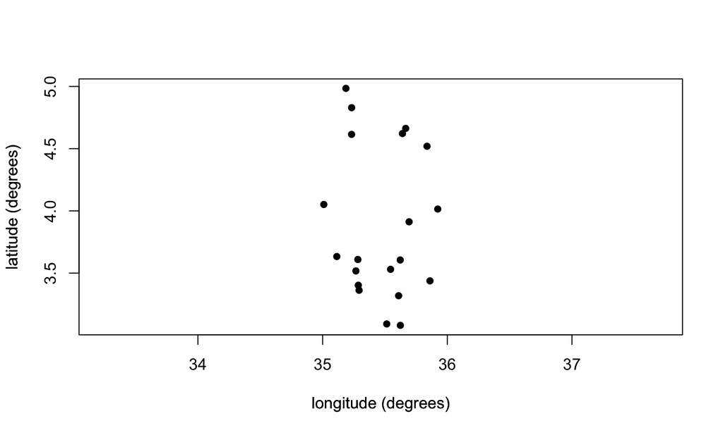

```r
plot(SFmyCoords, axes=TRUE, xlab="longitude (degrees)", ylab="latitude (degrees)", pch=16)
```

## fully spatial object

Now there are a plethora of spatial things you can do with these points that you couldn’t before

```r
#boundary box
st_bbox(SFmyCoords)
```

```
##      xmin      ymin      xmax      ymax
## 35.009496  3.079992 35.923433  4.984301
```

## fully spatial object

Add a buffer around the points, and then plot

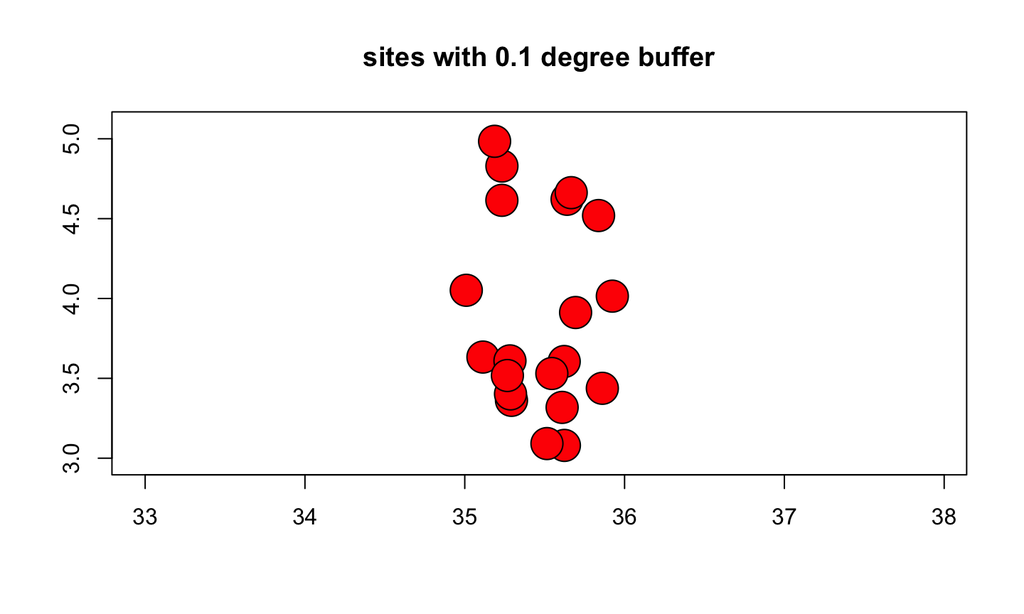

```r
buffered <- st_buffer(SFmyCoords, 0.1)
plot(buffered, axes=TRUE, col="red", main="sites with 0.1 degree buffer")
```

## fully spatial object

Check out the `sf` cheatsheet (here) to see the kind of spatial operations you can do

## `rnaturalearth`

The `rnaturalearth` package provides maps that you can use in your plots.

It can be a bit hard to install this package.

```
#try this first
install.packages(c("rnaturalearth", "rnaturalearthdata", "rnaturalearthhires"))

#if the above fails, try this
install.packages("devtools")
devtools::install_github("ropensci/rnaturalearth")
devtools::install_github("ropensci/rnaturalearthdata")
devtools::install_github("https://github.com/ropensci/rnaturalearthhires")
```

## `rnaturalearth`

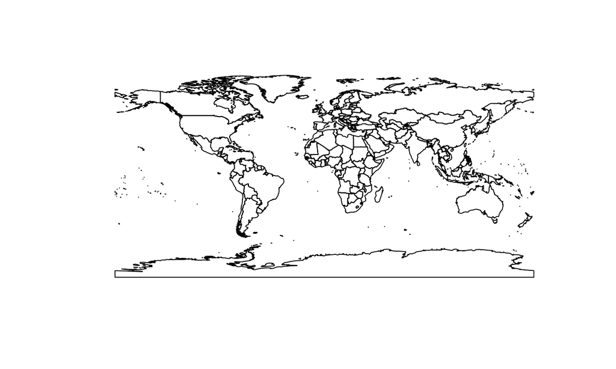

```r
library(rnaturalearth)
world <- ne_countries(scale = "medium", returnclass = "sf")
plot(st_geometry(world))
```

## These objects can have lots of attributes

Because these are `sf` objects, they have attributes in data.frame which come in handy later for plotting

```r
head(world)
```

```
## Simple feature collection with 6 features and 94 fields
## geometry type:  MULTIPOLYGON
## dimension:      XY
## bbox:           xmin: -73.36621 ymin: -22.40205 xmax: 109.4449 ymax: 41.9062
## CRS:            +proj=longlat +datum=WGS84 +no_defs +ellps=WGS84 +towgs84=0,0,0
##        featurecla scalerank labelrank sovereignt sov_a3 adm0_dif level
## 0 Admin-0 country         1         3   Zimbabwe    ZWE        0     2
## 1 Admin-0 country         1         3     Zambia    ZMB        0     2
## 2 Admin-0 country         1         3      Yemen    YEM        0     2
## 3 Admin-0 country         3         2    Vietnam    VNM        0     2
## 4 Admin-0 country         5         3  Venezuela    VEN        0     2
## 5 Admin-0 country         6         6    Vatican    VAT        0     2
##                type     admin adm0_a3 geou_dif   geounit gu_a3 su_dif   subunit
## 0 Sovereign country  Zimbabwe     ZWE        0  Zimbabwe   ZWE      0  Zimbabwe
## 1 Sovereign country    Zambia     ZMB        0    Zambia   ZMB      0    Zambia
```

[output cut: 102 more lines]

## works with `ggplot2` using `geom_sf`

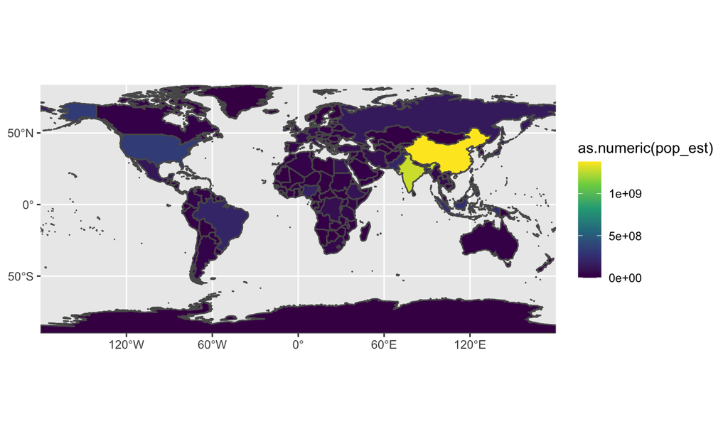

```r
library(ggplot2)
ggplot(data=world) +
  geom_sf(aes(fill=as.numeric(pop_est))) +
  scale_fill_viridis_c() +
  coord_sf(expand=F) #don't expand the map to an even number
```

## labeling

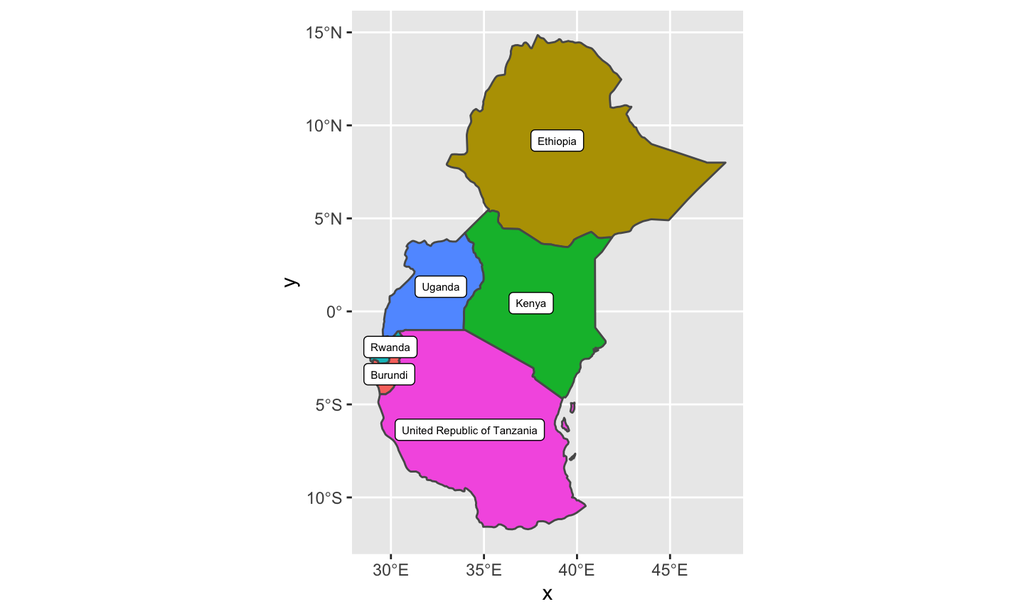

```r
countries <- ne_countries(scale="medium", country=c("Kenya", "United Republic of Tanzania", "Ethiopia", "Uganda", "Rwanda", "Burundi") ,returnclass = "sf")
ggplot(countries) +
  geom_sf(aes(fill=sovereignt)) + geom_sf_label(aes(label=sovereignt), size=2) + guides(fill="none")
```

## more detailed maps from `rnaturalearth`

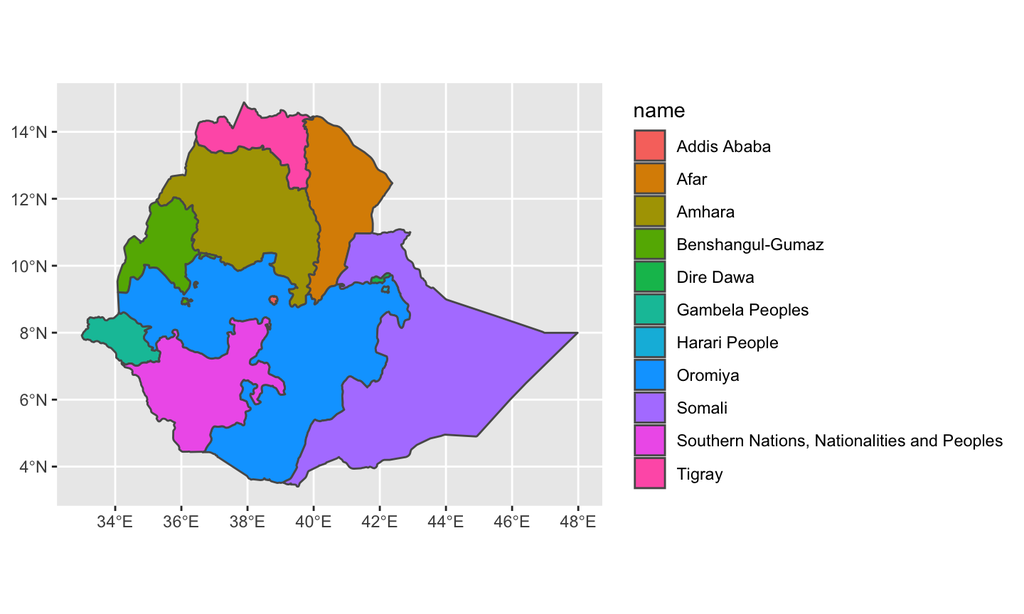

```r
ethiopia <- ne_states(country="Ethiopia", returnclass = "sf")
ggplot(ethiopia) +
  geom_sf(aes(fill=name))
```

## Challenge

Use `rnaturalearth::ne_countries()` to download map data for Brazil. Plot this and make it pretty.

## RGoogleMaps

[figure not shown]

```r
library("RgoogleMaps")
GW <- GetMap(center = c(38.899, -77.049), zoom = 17)
PlotOnStaticMap(GW)
```

## RGoogleMaps

[figure not shown]

```r
GWSatellite <- GetMap(center = c(38.899, -77.049), zoom = 17, maptype = "satellite")
PlotOnStaticMap(GWSatellite, lon=-77.0493, lat=38.899, pch=16, col="red", cex=2)
```

## GIS in R

You can do almost anything in R that you can do in ArcGIS.

This is accomplished through additional packages, notably `rgdal` which is an R interface to the Geospatial Data Abstraction Library (GDAL), which is a great piece of open source software for spatial analysis. GDAL is the brains behind QGIS.

The `spatstats` package also implements a variety of spatial statistics.

One issue: R can be very slow with raster data (e.g. images, satellite data etc) so if you are heavy into this you need to use other software.

## Ask me 3 questions about spatial data in R!